# COD Reproducibility Report

#### Methods summary:

In study 1, 20 participants rated the percieved warmth and competence of 1000 photographs of faces. These ratings were compared with previously collected ratings of trutworthiness and dominance, respectively, for each of the images to determine the similarity between the judgements. Correlations were used to compare each pair of ratings, and the magnitude of the correlations were compared using the Fisher’ Z transformation of the Pearson-Filon statistic.

#### Target outcomes:

> In order to assess the claim that trustworthiness and warmth are highly similar trait judgements, we correlated the warmth ratings from the current study with the previously collected trustworthiness ratings (Sutherland et al., 2013; see Fig. 2). The correlation between trustworthiness and warmth was substantial and highly significant: r = 0.78, p < 0.001, n = 1,000. Similarly, in order to assess the claim that dominance and competence are highly similar trait judgements, we correlated the competence ratings from the current study with the previously collected dominance ratings (Sutherland et al., 2013). The correlation for dominance and competence was significant but only moderate in size: r = 0.32, p < 0.001, n = 1,000. The size of the correlation between trustworthiness and warmth was significantly greater than the size of the correlation for dominance and competence: ZPF = 15.46, p < 0.001, n = 1,000 (for further details on the statistical test see Raghunathan, Rosenthal, & Rubin, 1996). It therefore appears that trustworthiness and warmth facial judgments are indeed highly similar. In contrast, dominance and competence facial judgments are less strongly related (see Fig. 2).

## Step 1: Load packages

```r
library(tidyverse) # for data munging
library(knitr) # for kable table formating
library(haven) # import and export 'SPSS', 'Stata' and 'SAS' Files
library(readxl) # import excel files
library(CODreports) # custom report functions
library(psych)
```

## Step 2: Load data

It looks like the data we need are in tabs 2, 3, 4 (start with “exp1”).

```r
exp1overall <- read_excel(path="data/data.xlsx", sheet="Exp1Overall")
exp1warm <- read_excel(path="data/data.xlsx", sheet="Exp1Warm")
exp1comp <- read_excel(path="data/data.xlsx", sheet="Exp1Comp")
```

## Step 3: Tidy data

Data seemed in sufficient format for analysis. However, since there were a few analysis columns in each the overall dataset, these columns were removed.

```r
exp1overall <- select(exp1overall, `Face identity`:Competence)
```

## Step 4: Run analysis

First, calculate inter-rater reliability for the collected warmth and competence ratings.

> The inter-rater reliabilities for warmth and competence were good (Cronbach’s alphas of a = 0.93 and a = 0.72 respectively).

```r
#Warmth ratings
alpha(as.matrix(select(exp1warm, starts_with("ppt"))))
```

```
##
## Reliability analysis
## Call: alpha(x = as.matrix(select(exp1warm, starts_with("ppt"))))
##
##   raw_alpha std.alpha G6(smc) average_r S/N    ase mean  sd
##       0.93      0.93    0.93      0.58  14 0.0034  4.1 1.2
##
##  lower alpha upper     95% confidence boundaries
## 0.92 0.93 0.93
##
##  Reliability if an item is dropped:
##       raw_alpha std.alpha G6(smc) average_r S/N alpha se
## ppt1       0.92      0.92    0.92      0.58  12   0.0038
## ppt2       0.92      0.93    0.92      0.59  13   0.0035
## ppt3       0.92      0.93    0.92      0.58  12   0.0037
## ppt4       0.92      0.93    0.92      0.58  13   0.0037
## ppt5       0.92      0.92    0.92      0.57  12   0.0038
## ppt7       0.92      0.93    0.92      0.58  12   0.0037
## ppt6       0.92      0.93    0.92      0.59  13   0.0036
## ppt8       0.91      0.92    0.92      0.56  12   0.0040
## ppt9       0.91      0.92    0.91      0.56  11   0.0040
## ppt10      0.92      0.93    0.92      0.59  13   0.0034
##
##  Item statistics
##          n raw.r std.r r.cor r.drop mean  sd
## ppt1  1000  0.80  0.80  0.77   0.74  3.9 1.5
## ppt2  1000  0.75  0.75  0.71   0.67  3.6 1.8
## ppt3  1000  0.77  0.79  0.76   0.73  3.4 1.1
## ppt4  1000  0.74  0.76  0.72   0.69  3.6 1.2
## ppt5  1000  0.81  0.81  0.78   0.76  4.3 1.5
## ppt7  1000  0.78  0.78  0.75   0.72  4.4 1.5
## ppt6  1000  0.74  0.75  0.70   0.68  4.3 1.5
## ppt8  1000  0.86  0.85  0.84   0.81  4.5 2.0
## ppt9  1000  0.88  0.88  0.88   0.85  4.4 1.4
## ppt10 1000  0.73  0.71  0.67   0.64  4.9 2.0
##
## Non missing response frequency for each item
##          1    2    3    4    5    6    7 miss
## ppt1  0.06 0.16 0.18 0.20 0.24 0.14 0.03    0
## ppt2  0.18 0.16 0.11 0.19 0.20 0.10 0.06    0
## ppt3  0.02 0.20 0.34 0.26 0.16 0.03 0.00    0
## ppt4  0.06 0.10 0.28 0.38 0.14 0.05 0.01    0
## ppt5  0.04 0.12 0.12 0.18 0.32 0.19 0.03    0
## ppt7  0.02 0.09 0.18 0.14 0.28 0.24 0.03    0
## ppt6  0.03 0.08 0.19 0.26 0.18 0.21 0.04    0
## ppt8  0.13 0.11 0.08 0.07 0.17 0.27 0.17    0
## ppt9  0.02 0.08 0.14 0.21 0.35 0.16 0.04    0
## ppt10 0.03 0.18 0.12 0.02 0.05 0.36 0.24    0
```

```r
#Competence ratings
alpha(as.matrix(select(exp1comp, starts_with("ppt"))))
```

```
##
## Reliability analysis
## Call: alpha(x = as.matrix(select(exp1comp, starts_with("ppt"))))
##
##   raw_alpha std.alpha G6(smc) average_r S/N   ase mean   sd
##       0.72      0.72    0.73      0.21 2.6 0.013  3.9 0.74
##
##  lower alpha upper     95% confidence boundaries
## 0.69 0.72 0.74
##
##  Reliability if an item is dropped:
##       raw_alpha std.alpha G6(smc) average_r S/N alpha se
## ppt1       0.70      0.70    0.71      0.21 2.3    0.014
## ppt2       0.66      0.67    0.67      0.18 2.0    0.016
## ppt3       0.71      0.72    0.72      0.22 2.5    0.013
## ppt4       0.66      0.67    0.67      0.18 2.0    0.016
## ppt5       0.72      0.73    0.73      0.23 2.7    0.013
## ppt7       0.69      0.69    0.70      0.20 2.2    0.014
## ppt6       0.73      0.74    0.74      0.24 2.8    0.012
## ppt8       0.68      0.68    0.68      0.19 2.1    0.015
## ppt9       0.70      0.71    0.72      0.21 2.4    0.014
## ppt10      0.68      0.69    0.69      0.20 2.2    0.015
##
##  Item statistics
##          n raw.r std.r r.cor r.drop mean  sd
## ppt1  1000  0.56  0.52  0.43   0.37  3.9 1.7
## ppt2  1000  0.70  0.70  0.67   0.57  4.0 1.5
## ppt3  1000  0.47  0.44  0.33   0.29  2.8 1.5
## ppt4  1000  0.68  0.70  0.68   0.57  3.3 1.3
## ppt5  1000  0.33  0.36  0.23   0.18  4.5 1.2
## ppt7  1000  0.54  0.57  0.51   0.42  4.1 1.1
## ppt6  1000  0.33  0.33  0.18   0.15  4.1 1.4
## ppt8  1000  0.63  0.64  0.61   0.52  4.3 1.2
## ppt9  1000  0.45  0.48  0.37   0.31  4.5 1.2
## ppt10 1000  0.62  0.59  0.54   0.45  3.9 1.7
##
## Non missing response frequency for each item
##          1    2    3    4    5    6    7 miss
## ppt1  0.06 0.18 0.23 0.15 0.15 0.16 0.06    0
## ppt2  0.03 0.15 0.19 0.27 0.18 0.11 0.06    0
## ppt3  0.26 0.16 0.31 0.12 0.09 0.05 0.00    0
## ppt4  0.05 0.26 0.30 0.19 0.13 0.06 0.01    0
## ppt5  0.00 0.04 0.15 0.32 0.28 0.15 0.05    0
## ppt7  0.01 0.07 0.14 0.44 0.22 0.10 0.01    0
## ppt6  0.02 0.09 0.24 0.29 0.22 0.04 0.10    0
## ppt8  0.01 0.07 0.18 0.27 0.32 0.15 0.01    0
## ppt9  0.01 0.06 0.15 0.23 0.37 0.17 0.01    0
## ppt10 0.06 0.19 0.16 0.14 0.24 0.17 0.04    0
```

The alphas match for both.

Next, run the correlation between trustworthiness and the average warmth rating.

> The correlation between trustworthiness and warmth was substantial and highly significant: r = 0.78, p < 0.001, n = 1,000.

```r
cor.test(exp1overall$Trustworthiness, exp1overall$Warmth)
```

```
##
##  Pearson's product-moment correlation
##
## data:  exp1overall$Trustworthiness and exp1overall$Warmth
## t = 39.013, df = 998, p-value < 2.2e-16
## alternative hypothesis: true correlation is not equal to 0
## 95 percent confidence interval:
##  0.7513592 0.8005761
## sample estimates:
##       cor
## 0.7771532
```

This matches what was reported.

Then, run the correlation between dominance and competence.

> The correlation for dominance and competence was significant but only moderate in size: r = 0.32, p < 0.001, n = 1,000.

```r
cor.test(exp1overall$Dominance, exp1overall$Competence)
```

```
##
##  Pearson's product-moment correlation
##
## data:  exp1overall$Dominance and exp1overall$Competence
## t = 10.757, df = 998, p-value < 2.2e-16
## alternative hypothesis: true correlation is not equal to 0
## 95 percent confidence interval:
##  0.2656405 0.3767896
## sample estimates:
##       cor
## 0.3223256
```

This also matches what was reported.

> The size of the correlation between trustworthiness and warmth was significantly greater than the size of the correlation for dominance and competence: ZPF = 15.46, p < 0.001, n = 1,000 (for further details on the statistical test see Raghunathan, Rosenthal, & Rubin, 1996). It therefore appears that trustworthiness and warmth facial judgments are indeed highly similar. In contrast, dominance and competence facial judgments are less strongly related (see Fig. 2).

Finally, compare the two correlation coefficients using the ZPF scoring algorithm described in Raghunathan et al., 1996.

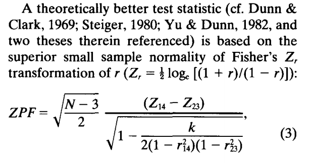

ZPF formula

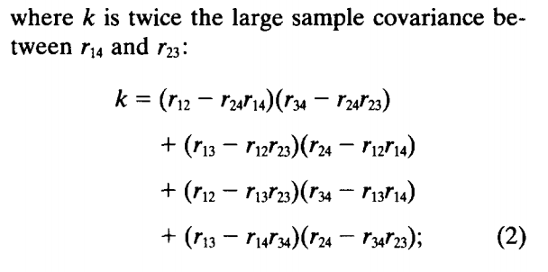

ZPF formula

First, take the z-transformation of each correlation coefficient, using the function “fisherz” in the psych package:

```r
rtw <- round(cor(exp1overall$Trustworthiness, exp1overall$Warmth), 2)
rcd <- round(cor(exp1overall$Competence, exp1overall$Dominance), 2)

#confirm this function is using the same formula as above
fisherz
```

```
## function (rho)
## {
##     0.5 * log((1 + rho)/(1 - rho))
## }
## <environment: namespace:psych>
```

```r
ztw <- fisherz(rtw)
zcd <- fisherz(rcd)
```

Next, calculate k

```r
rtc <- round(cor(exp1overall$Trustworthiness, exp1overall$Competence),2)
rcw <- round(cor(exp1overall$Warmth, exp1overall$Competence),2)
rdw <- round(cor(exp1overall$Dominance, exp1overall$Warmth), 2)
rtd <- round(cor(exp1overall$Trustworthiness, exp1overall$Dominance), 2)

(k = (rtc - rcw*rtw)*(rdw - rcw*rcd) +
    (rtd - rtc*rcd)*(rcw - rtc*rtw) +
    (rtc - rtd*rcd)*(rdw - rtd*rtw) +
    (rtd - rtw*rdw)*(rcw - rdw*rcd))
```

```
## [1] -0.023904
```

Then calculate the ZPF value.

```r
(ZPF <- sqrt((1000-3)/2)*(ztw - zcd)/sqrt(1 - (k/(2*(1-rtw^2)*(1-rcd^2)))))
```

```
## [1] 15.67118
```

Find the p value based on this z score (assume a two-tailed test).

```r
2*pnorm(1-ZPF)
```

```
## [1] 9.861617e-49
```

This looks close to what was reported, but with a slight numeric difference.

```r
compareValues(reportedValue = 15.46, obtainedValue = 15.67)
```

```
## [1] "MINOR NUMERICAL ERROR. The reported value (15.46) and the obtained value (15.67) differed by 1.36%. NB obtained value was rounded to 2 decimal places."
```

## Step 5: Conclusion

Overall, this dataset seemed sufficiently documented and the parts of Study 1 that were attempted replicated with only minor numeric errors.

```r
codReport(Report_Type = 'pilot',
          Article_ID = 'APNGu',
          Insufficient_Information_Errors = 0,
          Decision_Errors = 0,
          Major_Numerical_Errors = 0,
          Minor_Numerical_Errors = 1)
```

| Insufficient_Information_Errors | Decision_Errors | Major_Numerical_Errors | Minor_Numerical_Errors | Final_Outcome |
| --- | --- | --- | --- | --- |
| 0 | 0 | 0 | 1 | Success |

Overall, this analysis was straight forward, sufficiently described in the article, and the data was sufficiently documented. The only other reporting information that may have been helpful is how the authors calculated the ZPF scores - whether they used a statistical package, website, or did it by hand. That could help explain the minor numeric inconsistencies.

[output not shown]

[output cut: 88 more lines]

[output not shown]